# SPPH 504 Section 007 Lab (4c) Analyzing the analytic survey dataset

## 6.5 Add all of the significant interactions in one model

Note that we have 1 effect modifier, 1 interaction

```r
fit9 <- update(fit7, .~. + interaction(OA,age) + interaction(age,sex))
require(jtools)
summ(fit9, confint = TRUE, digits = 3)
```

| Observations | 148275 |
| --- | --- |
| Dependent variable | I(CVD == “event”) |
| Type | Survey-weighted generalized linear model |
| Family | quasibinomial |
| Link | logit |

| Pseudo-R² (Cragg-Uhler) | 0.129 |
| --- | --- |
| Pseudo-R² (McFadden) | 0.158 |
| AIC | NA |

|  | Est. | 2.5% | 97.5% | t val. | p |  |
| --- | --- | --- | --- | --- | --- | --- |
| (Intercept) | -5.319 | -5.796 | -4.841 | -21.839 | 0.000 | *** |
| OAOA | 0.377 | 0.178 | 0.577 | 3.708 | 0.000 | *** |
| age30-39 years | 0.595 | -0.124 | 1.313 | 1.623 | 0.105 |  |
| age40-49 years | 1.426 | 0.913 | 1.939 | 5.447 | 0.000 | *** |
| age50-59 years | 2.152 | 1.676 | 2.628 | 8.854 | 0.000 | *** |
| age60-64 years | 2.572 | 2.174 | 2.969 | 12.679 | 0.000 | *** |
| sexMale | 0.006 | -0.448 | 0.461 | 0.027 | 0.979 |  |
| marriedsingle | -0.115 | -0.234 | 0.004 | -1.888 | 0.059 | . |
| raceWhite | 0.252 | 0.029 | 0.474 | 2.214 | 0.027 | * |
| income$30,000-$49,999 | -0.434 | -0.582 | -0.285 | -5.714 | 0.000 | *** |
| income$50,000-$79,999 | -0.563 | -0.710 | -0.417 | -7.528 | 0.000 | *** |
| income$80,000 or more | -0.656 | -0.813 | -0.499 | -8.178 | 0.000 | *** |
| doctorYes | 0.505 | 0.293 | 0.718 | 4.661 | 0.000 | *** |
| stressstressed | 0.268 | 0.154 | 0.382 | 4.617 | 0.000 | *** |
| smokeCurrent smoker | 0.186 | 0.033 | 0.339 | 2.376 | 0.018 | * |
| smokeFormer smoker | 0.180 | 0.042 | 0.318 | 2.561 | 0.010 | * |
| drinkCurrent drinker | -0.284 | -0.562 | -0.006 | -2.004 | 0.045 | * |
| drinkFormer driker | 0.064 | -0.233 | 0.361 | 0.425 | 0.671 |  |
| fruit4-6 daily serving | -0.144 | -0.266 | -0.021 | -2.290 | 0.022 | * |
| fruit6+ daily serving | 0.055 | -0.104 | 0.214 | 0.683 | 0.494 |  |
| bpYes | 1.044 | 0.925 | 1.163 | 17.213 | 0.000 | *** |
| diabYes | 0.759 | 0.591 | 0.926 | 8.865 | 0.000 | *** |
| interaction(OA, age)OA.20-29 years | -0.188 | -1.428 | 1.052 | -0.297 | 0.766 |  |
| interaction(OA, age)Control.30-39 years | -0.327 | -0.923 | 0.268 | -1.077 | 0.281 |  |
| interaction(OA, age)Control.40-49 years | -0.298 | -0.652 | 0.057 | -1.645 | 0.100 | . |
| interaction(OA, age)Control.50-59 years | -0.055 | -0.350 | 0.239 | -0.366 | 0.714 |  |
| interaction(age, sex)30-39 years.Female | 0.009 | -0.577 | 0.594 | 0.029 | 0.976 |  |
| interaction(age, sex)40-49 years.Female | -0.294 | -0.797 | 0.208 | -1.149 | 0.251 |  |
| interaction(age, sex)50-59 years.Female | -0.747 | -1.239 | -0.256 | -2.983 | 0.003 | ** |
| interaction(age, sex)60-64 years.Female | -0.703 | -1.192 | -0.215 | -2.823 | 0.005 | ** |

Standard errors: Robust

```r
fit9 <- update(fit7, .~. + OA:age + age:sex)
publish(fit9)
```

```
##                                      Variable             Units Coefficient         CI.95     p-value
##                                       married        not single         Ref
##                                                          single       -0.11  [-0.23;0.00]   0.0590843
##                                          race         Non-white         Ref
##                                                           White        0.25   [0.03;0.47]   0.0268037
##                                        income   $29,999 or less         Ref
##                                                 $30,000-$49,999       -0.43 [-0.58;-0.28]     < 1e-04
##                                                 $50,000-$79,999       -0.56 [-0.71;-0.42]     < 1e-04
##                                                 $80,000 or more       -0.66 [-0.81;-0.50]     < 1e-04
##                                        doctor                No         Ref
##                                                             Yes        0.51   [0.29;0.72]     < 1e-04
##                                        stress  Not too stressed         Ref
##                                                        stressed        0.27   [0.15;0.38]     < 1e-04
##                                         smoke      Never smoker         Ref
##                                                  Current smoker        0.19   [0.03;0.34]   0.0175106
##                                                   Former smoker        0.18   [0.04;0.32]   0.0104241
##                                         drink       Never drank         Ref
##                                                 Current drinker       -0.28 [-0.56;-0.01]   0.0450673
##                                                   Former driker        0.06  [-0.23;0.36]   0.6711287
##                                         fruit 0-3 daily serving         Ref
##                                               4-6 daily serving       -0.14 [-0.27;-0.02]   0.0220441
##                                                6+ daily serving        0.06  [-0.10;0.21]   0.4943998
##                                            bp                No         Ref
##                                                             Yes        1.04   [0.93;1.16]     < 1e-04
##                                          diab                No         Ref
##                                                             Yes        0.76   [0.59;0.93]     < 1e-04
##  OA(Control): age(30-39 years vs 20-29 years)                          0.28  [-0.11;0.66]   0.1609925
##  OA(Control): age(40-49 years vs 20-29 years)                          0.83   [0.51;1.16]     < 1e-04
##  OA(Control): age(50-59 years vs 20-29 years)                          1.35   [1.02;1.68]     < 1e-04
##  OA(Control): age(60-64 years vs 20-29 years)                          1.87   [1.54;2.20]     < 1e-04
##       OA(OA): age(30-39 years vs 20-29 years)                          0.79  [-0.55;2.13]   0.2477875
##       OA(OA): age(40-49 years vs 20-29 years)                          1.32   [0.05;2.59]   0.0414707
##       OA(OA): age(50-59 years vs 20-29 years)                          1.59   [0.34;2.84]   0.0124767
##       OA(OA): age(60-64 years vs 20-29 years)                          2.06   [0.81;3.31]   0.0012548
##           age(20-29 years): OA(OA vs Control)                          0.19  [-1.04;1.41]   0.7619778
##           age(30-39 years): OA(OA vs Control)                          0.70   [0.14;1.27]   0.0139139
##           age(40-49 years): OA(OA vs Control)                          0.67   [0.38;0.97]     < 1e-04
##           age(50-59 years): OA(OA vs Control)                          0.43   [0.22;0.65]     < 1e-04
##           age(60-64 years): OA(OA vs Control)                          0.38   [0.18;0.58]   0.0002088
##         age(20-29 years): sex(Male vs Female)                          0.01  [-0.45;0.46]   0.9785115
##         age(30-39 years): sex(Male vs Female)                         -0.00  [-0.38;0.37]   0.9893605
##         age(40-49 years): sex(Male vs Female)                          0.30   [0.08;0.52]   0.0074894
##         age(50-59 years): sex(Male vs Female)                          0.75   [0.56;0.95]     < 1e-04
##         age(60-64 years): sex(Male vs Female)                          0.71   [0.52;0.90]     < 1e-04
##  sex(Female): age(30-39 years vs 20-29 years)                          0.28  [-0.11;0.66]   0.1609925
##  sex(Female): age(40-49 years vs 20-29 years)                          0.83   [0.51;1.16]     < 1e-04
##  sex(Female): age(50-59 years vs 20-29 years)                          1.35   [1.02;1.68]     < 1e-04
##  sex(Female): age(60-64 years vs 20-29 years)                          1.87   [1.54;2.20]     < 1e-04
##    sex(Male): age(30-39 years vs 20-29 years)                          0.27  [-0.19;0.73]   0.2540774
##    sex(Male): age(40-49 years vs 20-29 years)                          1.13   [0.73;1.53]     < 1e-04
##    sex(Male): age(50-59 years vs 20-29 years)                          2.10   [1.71;2.48]     < 1e-04
##    sex(Male): age(60-64 years vs 20-29 years)                          2.57   [2.17;2.97]     < 1e-04
```

# 7 Model performance

## 7.1 ROC curve

- The appropriateness of the fitted logistic regression model needs to be examined before it is accepted for use.
- Plotting the pairs of - sensitivities vs - 1-specificities on a scatter plot provides a Receiver Operating Characteristic (ROC) curve.
- The area under the ROC curve = AUC / C-statistic.
- ROC/AUC should consider weights for complex surveys.

Grading Guidelines for AUC values:

- 0.90-1.0 excellent discrimination (unusual)
- 0.80-0.90 good discrimination
- 0.70-0.80 fair discrimination
- 0.60-0.70 poor discrimination
- 0.50-0.60 failed discrimination

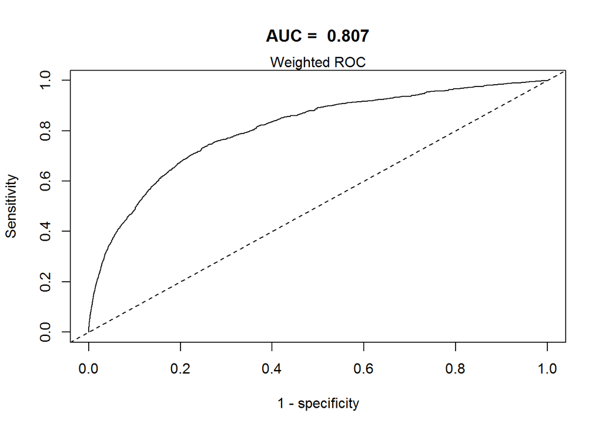

```r
require(ROCR)
# WeightedROC may not be on cran for all R versions
# devtools::install_github("tdhock/WeightedROC")
library(WeightedROC)
svyROCw <- function(fit=fit7,outcome=analytic2$CVD=="event", weight = NULL){
  # ROC curve for
  # Survey Data with Logistic Regression
  if (is.null(weight)){ # require(ROCR)
    prob <- predict(fit, type = "response")
  pred <- prediction(as.vector(prob), outcome)
  perf <- performance(pred, "tpr", "fpr")
  auc <- performance(pred, measure = "auc")
  auc <- auc@y.values[[1]]
  roc.data <- data.frame(fpr = unlist(perf@x.values), tpr = unlist(perf@y.values),
      model = "Logistic")
  with(data = roc.data,plot(fpr, tpr, type="l", xlim=c(0,1), ylim=c(0,1), lwd=1,
     xlab="1 - specificity", ylab="Sensitivity",
     main = paste("AUC = ", round(auc,3))))
  mtext("Unweighted ROC")
  abline(0,1, lty=2)
  } else { # library(WeightedROC)
    outcome <- as.numeric(outcome)
  pred <- predict(fit, type = "response")
  tp.fp <- WeightedROC(pred, outcome, weight)
  auc <- WeightedAUC(tp.fp)
  with(data = tp.fp,plot(FPR, TPR, type="l", xlim=c(0,1), ylim=c(0,1), lwd=1,
     xlab="1 - specificity", ylab="Sensitivity",
     main = paste("AUC = ", round(auc,3))))
  abline(0,1, lty=2)
  mtext("Weighted ROC")
  }
}
svyROCw(fit=fit7,outcome=analytic2$CVD=="event", weight = analytic2$weight)
```

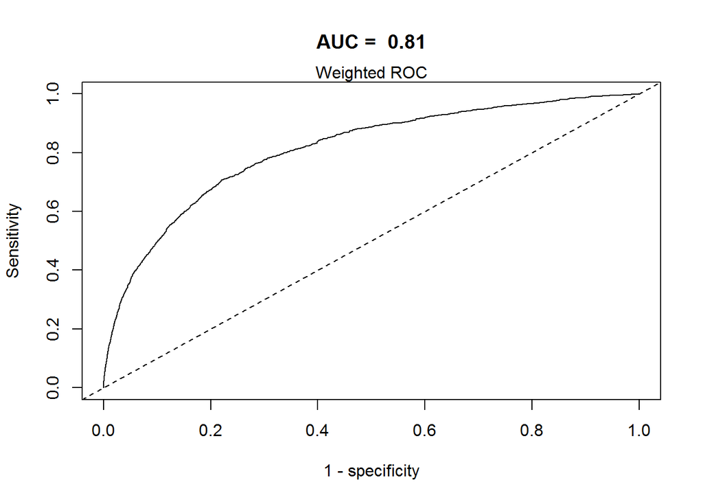

```r
svyROCw(fit=fit9,outcome=analytic2$CVD=="event", weight = analytic2$weight)
```

```r
# This function does not take in to account of strata/cluster
```

## 7.2 Archer and Lemeshow test

- Hosmer Lemeshow-type tests are most useful as a very crude way to screen for fit problems, and should not be taken as a definitive diagnostic of a ‘good’ fit.
  - problem in small sample size
  - Dependent on G (group)
- Archer and Lemeshow (2006) extended the standard Hosmer and Lemeshow GOF test for complex surveys.
- After fitting the survey weighted logistic regression, the F-adjusted mean residual goodness-of-fit test could suggest
  - no evidence of lack of fit (if P-value > a reasonable cut-point, e.g., 0.05)
  - evidence of lack of fit (if P-value < a reasonable cut-point, e.g., 0.05)

```r
AL.gof <- function(fit=fit7, data = analytic2,
                   weight = "weight"){
  # Archer-Lemeshow Goodness of Fit Test for
  # Survey Data with Logistic Regression
  r <- residuals(fit, type="response")
  f<-fitted(fit)
  breaks.g <- c(-Inf, quantile(f,  (1:9)/10), Inf)
  breaks.g <- breaks.g + seq_along(breaks.g) * .Machine$double.eps
  g<- cut(f, breaks.g)
  data2g <- cbind(data,r,g)
  newdesign <- svydesign(id=~1,
                         weights=as.formula(paste0("~",weight)),
                        data=data2g)
  decilemodel<- svyglm(r~g, design=newdesign)
  res <- regTermTest(decilemodel, ~g)
  return(res)
}
AL.gof(fit7, analytic2,weight = "weight")
```

```
## Wald test for g
##  in svyglm(formula = r ~ g, design = newdesign)
## F =  2.020121  on  9  and  148265  df: p= 0.033137
```

```r
# Evidence of poor fit
AL.gof(fit9, analytic2,weight = "weight")
```

```
## Wald test for g
##  in svyglm(formula = r ~ g, design = newdesign)
## F =  0.539824  on  9  and  148265  df: p= 0.84647
```

```r
# No evidence of lack of fit
```

If the survey data contains strata and cluster, then the following function will be useful:

```r
AL.gof2 <- function(fit=fit7, data = analytic2,
                   weight = "weight", psu = "psu", strata= "strata"){
  # Archer-Lemeshow Goodness of Fit Test for
  # Survey Data with Logistic Regression
  r <- residuals(fit, type="response")
  f<-fitted(fit)
  breaks.g <- c(-Inf, quantile(f,  (1:9)/10), Inf)
  breaks.g <- breaks.g + seq_along(breaks.g) * .Machine$double.eps
  g<- cut(f, breaks.g)
  data2g <- cbind(data,r,g)
  newdesign <- svydesign(id=as.formula(paste0("~",psu)),
                         strata=as.formula(paste0("~",strata)),
                         weights=as.formula(paste0("~",weight)),
                        data=data2g, nest = TRUE)
  decilemodel<- svyglm(r~g, design=newdesign)
  res <- regTermTest(decilemodel, ~g)
  return(res)
}
```

# 8 Various measures of association

```r
require(jtools)
# RR: may need starting value
fit00 <- svyglm(I(CVD=="event") ~ OA + age + sex,
               design = w.design,
       family = quasibinomial(log))
summ(fit00, confint = TRUE, digits = 3, vifs = TRUE)
```

| Observations | 148275 |
| --- | --- |
| Dependent variable | I(CVD == “event”) |
| Type | Survey-weighted generalized linear model |
| Family | quasibinomial |
| Link | log |

| Pseudo-R² (Cragg-Uhler) | 0.089 |
| --- | --- |
| Pseudo-R² (McFadden) | 0.109 |
| AIC | NA |

|  | Est. | 2.5% | 97.5% | t val. | p | VIF |  |
| --- | --- | --- | --- | --- | --- | --- | --- |
| (Intercept) | -5.534 | -5.768 | -5.299 | -46.207 | 0.000 | NA | *** |
| OAOA | 0.613 | 0.489 | 0.737 | 9.680 | 0.000 | 1.211 | *** |
| age30-39 years | 0.393 | 0.102 | 0.684 | 2.646 | 0.008 | 1.125 | ** |
| age40-49 years | 1.256 | 1.006 | 1.505 | 9.863 | 0.000 | 1.125 | *** |
| age50-59 years | 2.206 | 1.965 | 2.447 | 17.930 | 0.000 | 1.125 | *** |
| age60-64 years | 2.829 | 2.587 | 3.071 | 22.932 | 0.000 | 1.125 | *** |
| sexMale | 0.453 | 0.353 | 0.554 | 8.857 | 0.000 | 1.119 | *** |

Standard errors: Robust

```r
confint(fit00)
```

```
##                     2.5 %     97.5 %
## (Intercept)    -5.7684089 -5.2989678
## OAOA            0.4888528  0.7370603
## age30-39 years  0.1018194  0.6839069
## age40-49 years  1.0062620  1.5053432
## age50-59 years  1.9650418  2.4473588
## age60-64 years  2.5874013  3.0710087
## sexMale         0.3530983  0.5537736
```

```r
# RD: may need starting value
fit10 <- svyglm(as.numeric(I(CVD=="event")) ~ OA + age + sex,
               design = w.design)
summ(fit10, confint = TRUE, digits = 3, vifs = TRUE)
```

| Observations | 148275 |
| --- | --- |
| Dependent variable | as.numeric(I(CVD == “event”)) |
| Type | Survey-weighted linear regression |

| R² | 0.031 |
| --- | --- |
| Adj. R² | 0.031 |

|  | Est. | 2.5% | 97.5% | t val. | p | VIF |  |
| --- | --- | --- | --- | --- | --- | --- | --- |
| (Intercept) | -0.000 | -0.002 | 0.001 | -0.537 | 0.591 | NA |  |
| OAOA | 0.030 | 0.022 | 0.037 | 7.653 | 0.000 | 1.102 | *** |
| age30-39 years | 0.002 | 0.000 | 0.004 | 2.376 | 0.018 | 1.102 | * |
| age40-49 years | 0.012 | 0.010 | 0.015 | 10.279 | 0.000 | 1.102 | *** |
| age50-59 years | 0.043 | 0.038 | 0.047 | 19.112 | 0.000 | 1.102 | *** |
| age60-64 years | 0.091 | 0.083 | 0.099 | 22.490 | 0.000 | 1.102 | *** |
| sexMale | 0.010 | 0.008 | 0.012 | 8.522 | 0.000 | 1.111 | *** |

Standard errors: Robust

```r
confint(fit10)
```

```
##                        2.5 %      97.5 %
## (Intercept)    -0.0021209619 0.001208741
## OAOA            0.0219674305 0.037093876
## age30-39 years  0.0003915943 0.004084993
## age40-49 years  0.0098795283 0.014534889
## age50-59 years  0.0382781141 0.047026244
## age60-64 years  0.0829154090 0.098747167
## sexMale         0.0078235916 0.012497137
```

```r
# OR
fit11 <- svyglm(I(CVD=="event") ~ OA + age + sex,
               design = w.design,
       family = quasibinomial(logit))
summ(fit11, confint = TRUE, digits = 3, vifs = TRUE)
```

| Observations | 148275 |
| --- | --- |
| Dependent variable | I(CVD == “event”) |
| Type | Survey-weighted generalized linear model |
| Family | quasibinomial |
| Link | logit |

| Pseudo-R² (Cragg-Uhler) | 0.089 |
| --- | --- |
| Pseudo-R² (McFadden) | 0.109 |
| AIC | NA |

|  | Est. | 2.5% | 97.5% | t val. | p | VIF |  |
| --- | --- | --- | --- | --- | --- | --- | --- |
| (Intercept) | -5.542 | -5.779 | -5.305 | -45.766 | 0.000 | NA | *** |
| OAOA | 0.669 | 0.533 | 0.805 | 9.634 | 0.000 | 1.193 | *** |
| age30-39 years | 0.394 | 0.102 | 0.687 | 2.639 | 0.008 | 1.100 | ** |
| age40-49 years | 1.266 | 1.015 | 1.518 | 9.863 | 0.000 | 1.100 | *** |
| age50-59 years | 2.246 | 2.002 | 2.491 | 18.037 | 0.000 | 1.100 | *** |
| age60-64 years | 2.929 | 2.684 | 3.175 | 23.363 | 0.000 | 1.100 | *** |
| sexMale | 0.474 | 0.367 | 0.581 | 8.666 | 0.000 | 1.131 | *** |

Standard errors: Robust

```r
confint(fit11)
```

```
##                     2.5 %     97.5 %
## (Intercept)    -5.7794347 -5.3047465
## OAOA            0.5326286  0.8047101
## age30-39 years  0.1015359  0.6874415
## age40-49 years  1.0145166  1.5177050
## age50-59 years  2.0023787  2.4905955
## age60-64 years  2.6835358  3.1750281
## sexMale         0.3669260  0.5814012
```